# Evaluating the Impact of Female Representation on the Popularity of Movie Films

#### Devica Shah

Last Updated: December 5, 2023

## 1. Introduction

This projects analyzes whether the female representation of the movie’s cast and crew have a relation to the popularity of the movie. The genre of each film will also be taken into account to analyze its effect on the popularity of movies. To address this question, I used a data set from Kaggle that received information from a list of movies with their Bechdel Test Score<sup>[3]</sup>. The Bechdel Test is a test with three principles: (1) there must be two women, (2) the two women must talk to each other, and (3) the women must discuss something other than a man. The dataset combines this information with other factors that involve female representation and other general movie data (such as genre, countries the movie was filmed in, and year). The data set was last updated in June 2022.

This study will specifically analyze the variables of popularity, cast_female_representation, crew_female_representation, genre, and popularity. It is important to analyze the female percentage of the crew because the crew makes crucial decisions in the film-making process that impact the ultimate movie.

Here is a snapshot of 5 randomly sampled rows of the data we will use:

5 Randomly Sampled Movie Listings

| cast_female_representation | crew_female_representation | genres | popularity |
| --- | --- | --- | --- |
| 2.777778 | 11.475410 | ['Action'] | 11.845 |
| 16.666667 | 17.391304 | ['Animation', 'Drama', 'Mystery', 'Science Fiction'] | 17.185 |
| 23.529412 | 22.222222 | ['Romance', 'Drama'] | 9.313 |
| 25.000000 | 5.660377 | ['Crime', 'Thriller'] | 6.948 |
| 19.354839 | 5.940594 | ['Action', 'Thriller'] | 68.707 |

## 2. Exploratory Data Analysis

The study had an original sample size of 7,279 movies. Although, 2,924 movies had a revenue of 0. Since, I could not establish why the movies had no revenue and I did not want to include films that may have potentially never released, the movies were removed. So my total sample size was 4355 (Table 1).

There are two values in the dataset that represent female representation: (1) the percentage of the cast that is female and (2) the percentage of the crew that is female. I had to decide how to incorporate both variables into the study. I found that the two variables have a correlation of 0.32, using the Pearson correlation coefficient test. Based on this correlation, I decided to average the two variables and create a new variable holding this information. This variable was assessed throughout this study to represent the female representation in the movie-making process.

The movies in the data set include a large number of possible genre combinations, making it difficult to conduct a study on each combinations’ impact on popularity of the movie. To simplify the analysis of genre in the study, I decided to only take the first genre mentioned in each movie to prevent cross listings.

Table 1: Summary Statistics of Popularity for Each Movie Genre

| genre | n | mean | median | min | max | sd |
| --- | --- | --- | --- | --- | --- | --- |
| 'Action' | 566 | 44.433726 | 21.6245 | 2.353 | 1608.867 | 97.779667 |
| 'Adventure' | 309 | 41.792178 | 19.9530 | 0.600 | 667.613 | 68.679700 |
| 'Animation' | 144 | 53.049986 | 43.2985 | 0.600 | 187.505 | 42.983441 |
| 'Comedy' | 919 | 17.111000 | 10.3080 | 1.233 | 203.256 | 20.689425 |
| 'Crime' | 201 | 19.781711 | 11.5010 | 0.600 | 202.333 | 23.197775 |
| 'Documentary' | 18 | 7.766667 | 8.1475 | 0.970 | 14.748 | 2.934744 |
| 'Drama' | 1111 | 15.546914 | 9.7870 | 0.600 | 242.051 | 18.823789 |
| 'Family' | 97 | 34.697309 | 21.3240 | 4.958 | 140.217 | 32.470807 |
| 'Fantasy' | 118 | 40.670483 | 21.4905 | 2.111 | 374.726 | 48.120589 |
| 'History' | 18 | 12.595444 | 7.6265 | 4.604 | 58.259 | 12.429391 |
| 'Horror' | 303 | 30.088630 | 21.0740 | 1.184 | 201.471 | 27.659099 |
| 'Music' | 33 | 15.946182 | 11.2360 | 3.985 | 53.856 | 12.974584 |
| 'Mystery' | 50 | 20.862180 | 12.9525 | 5.620 | 141.267 | 21.704395 |
| 'Romance' | 119 | 21.534731 | 11.7710 | 1.999 | 230.635 | 29.966424 |
| 'Science Fiction' | 113 | 34.910301 | 18.9230 | 4.752 | 298.737 | 39.852598 |
| 'Thriller' | 174 | 21.329471 | 14.4035 | 5.254 | 134.389 | 20.708461 |
| 'War' | 28 | 29.189143 | 16.1770 | 0.600 | 173.852 | 35.568966 |
| 'Western' | 34 | 16.982529 | 11.8745 | 3.230 | 99.502 | 17.494491 |

The distribution in Figure 1 looks relatively normal, but with right tail. Based on the distribution of the Percentage of Female Representation, there is so need for any transformations.

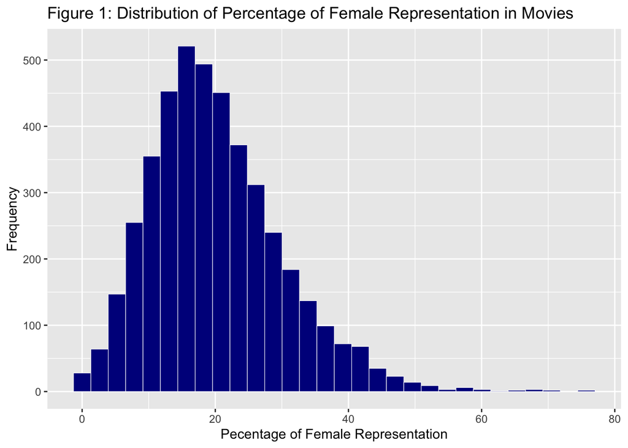

Figure 2 displays a graph of the distribution of popularity. Since the graph is skewed right, a logarithmic transformation was applied to the popularity variable.

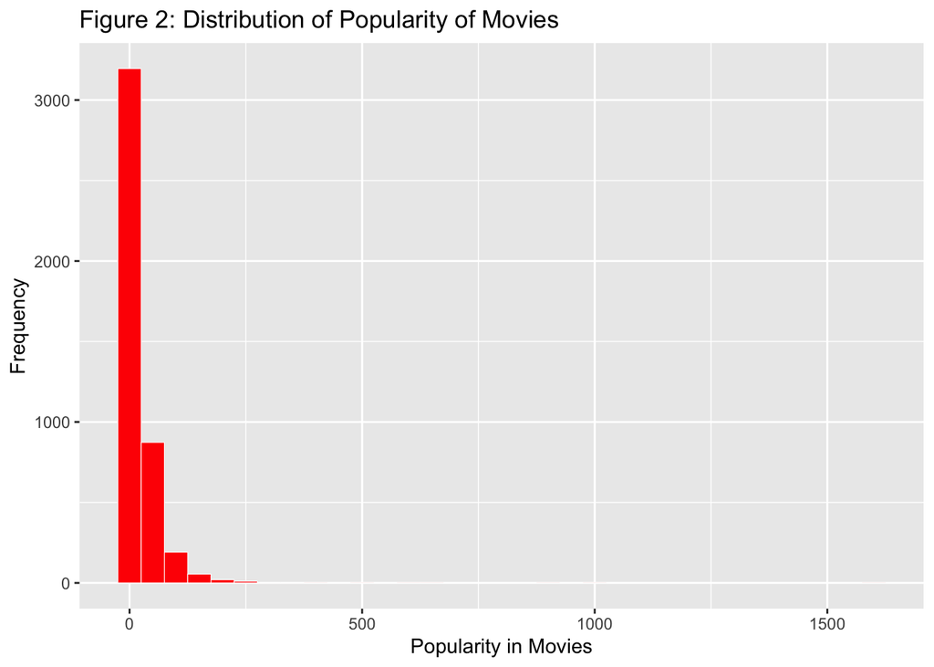

The distribution of the transformed popularity variable has a normal distribution (Figure 3).

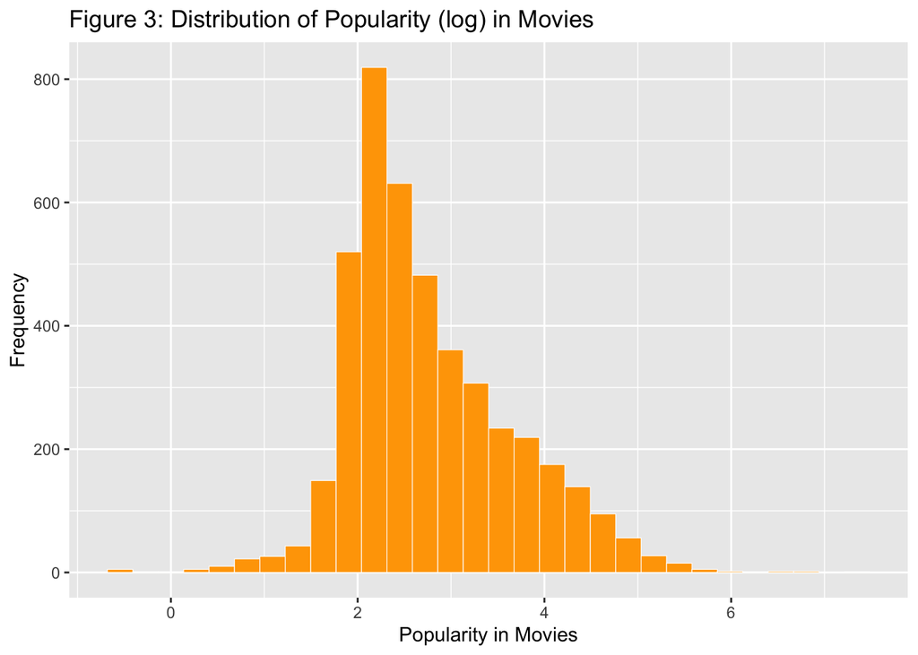

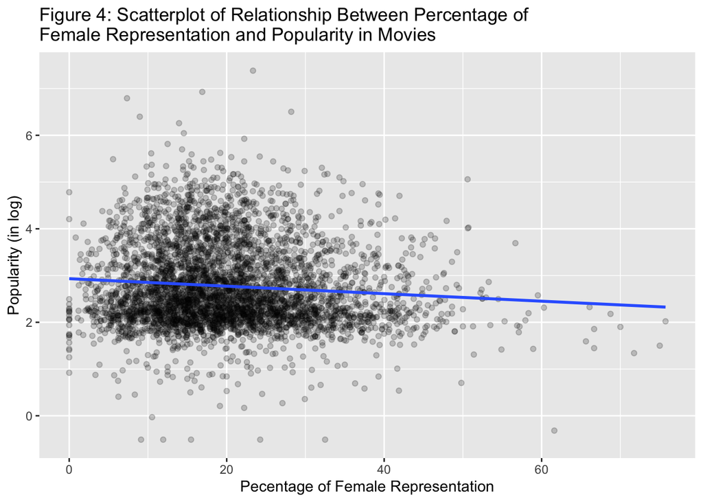

In Figure 5, the boxplots demonstrate the relationship between the numerical outcome variable (Popularity) and numerical categorical variable (genre of movie). To display a better representation of the relationship between genre and popularity of movies, the graph’s popularity was limited to 250. The differences between each genre seem to be different. The median of the popularity of animation genres is highest within all the genres. The upper quartiles for the genres are relatively different. There are also many outliers for every genre.

[figure not shown]

The trend of each genre shown in Figure 6 has a slight relationship. The relationships do not seem to be drastically different from each other. However, some genres have a positive relationship with popularity (ei. Action, Documentary), while other have a negative one (ei. Animation, War).

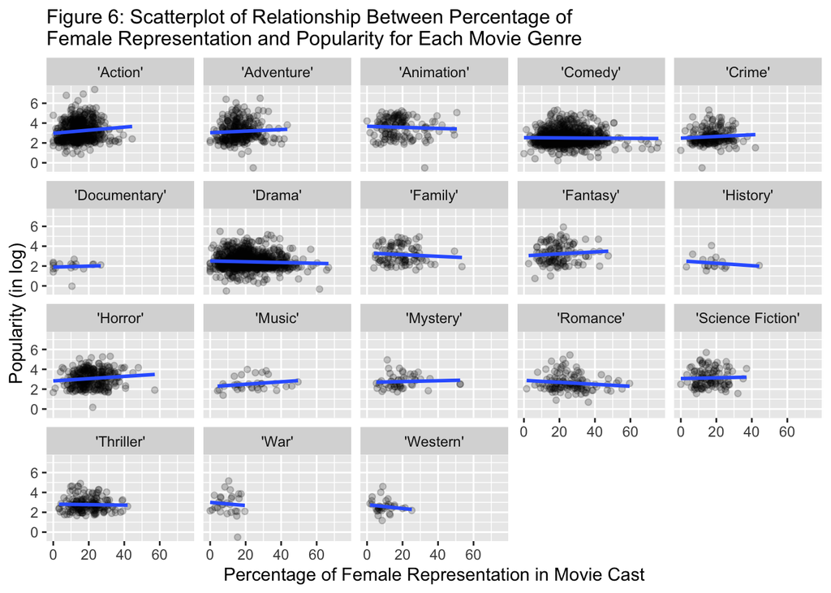

## 3. Regression

### 3.1 Methods

The components of our regression models are listed below:

- Outcome variable, y = Popularity of Movies
- Numerical explanatory variable, x<sub>1</sub> = Percentage of Female Representation
- Categorical explanatory variable, x<sub>2</sub> = Genre

where the unit of analysis is movie, given that each row in the data set corresponds to a different movie.

### 3.2 Model Results and Interpretation

**Model 1** only used the outcome variable (popularity) and numerical explanatory variable (percent of female representation). This model assumes no other factors affect popularity.

*log_popularity* = *b*<sub>0</sub> + *b<sub>fem</sub>* • *fem*

*log_popularity* = 2.933 - 0.008(*fem*)

Since we transformed the outcome variable, the result of the formula (popularity) will be in logarithmic units.

- The intercept (*b*<sub>0</sub> = 2.933) represents the popularity of a movie when the percentage of female representation is zero.
- The estimate for the slope for percent of female representation (*b<sub>fem</sub> = -*0.008) is the associated change in popularity depending on the percentage of female representation in movies. Based on this estimate, for every one percentage point increase in the percent of female representation in a movie, there was an associated decrease in popularity of the film of, on average, 0.008 units of popularity (in log).

**Model 2** uses the outcome variable (popularity), the numerical explanatory variable (percent of female representation), and the categorical explanatory variable (genre).

*log_popularity* = *b*<sub>0</sub> + *b*<sub>fem</sub> • fem + *b<sub>Genre</sub>* • 1<sub>*is Genre*</sub> (x)

*log_popularity* = 3.2 + *b<sub>Genre</sub>* • 1<sub>*is Genre*</sub> (x)

- The intercept (*b*<sub>0</sub> = 3.2) represents the popularity of a movie when the percentage of female representation is zero and the genre is action.
- Since the estimate for the slope for percent of female representation (*b<sub>fem</sub> = 0.000*) is the associated change in popularity depending on the percentage of female representation in movies, than it indicated that female representation has no affect on popularity.
- The estimate for the genre are offsets (*b<sub>Genre</sub>*) in intercept relative to the baseline group’s action genre. Each genre has its own distinct offset (ex. *b<sub>Adventure</sub>* = -0.041). Some genres have a offset higher (a positive coefficient) than the baseline, while others have a lower one (a negative coefficient).

**Model 3** uses all three variables.

*log_popularity* = *b*<sub>0</sub> + *b*<sub>fem</sub> • fem + *b<sub>Genre</sub>* • 1<sub>*is Genre*</sub> (x) + *b<sub>fem,Genre</sub>* • f*em* • 1<sub>*is Genre*</sub> (x)

*log_popularity* = 2.976 + 0.015 • fem + *b<sub>Genre</sub>* • 1<sub>*is Genre*</sub> (x) + *b<sub>fem,Genre</sub>* • f*em* • 1<sub>*is Genre*</sub> (x)

- The intercept (*b*<sub>0</sub> = 2.976) represents the popularity of a movie when the percentage of female representation is zero and the genre is action.
- The estimate for the slope for percent of female representation (*b<sub>fem</sub> =* 0.015) is the associated change in popularity depending on the percentage of female representation in movies. Based on this estimate, for every one percentage point increase in the percent of female representation in a movie, there was an associated increase in popularity of the film of, on average, 0.015 units of popularity (in log).
- The estimate for the genre (*b<sub>Genre</sub>*) are offsets in intercept relative to the baseline group’s action genre. Some genres have a offset higher, while others have a lower one.
- The interaction between female representation and genre are an addition to the formula. It captures how the effect of female representation on popularity, may be due to a difference in genre. The estimate (*b<sub>fem,Genre</sub>*) is dependent on the genre.

**Model 4** uses all three variables. Only selected rows of the table are displayed to make the visualization simpler.

*log_popularity* = *b*<sub>0</sub> + *b*<sub>fem</sub> • fem + *b*<sub>fem2</sub> • fem<sup>2</sup> + *b<sub>Genre</sub>* • 1<sub>*is Genre*</sub> (x) + *b<sub>fem,Genre</sub>* • f*em* • 1<sub>*is Genre*</sub> (x) + *b<sub>fem2,Genre</sub>* • *fem*<sup>2</sup>• 1<sub>*is Genre*</sub> (x)

*log_popularity* = 2.416 + 0.098 • fem - 0.003 • fem<sup>2</sup> + *b<sub>Genre</sub>* • 1<sub>*is Genre*</sub> (x) + *b<sub>fem,Genre</sub>* • f*em* • 1<sub>*is Genre*</sub> (x) + *b<sub>fem2,Genre</sub>* • *fem*<sup>2</sup>• 1<sub>*is Genre*</sub> (x)

- The intercept (*b*<sub>0</sub> = 2.416) represents the popularity of a movie when the percentage of female representation is zero and the genre is action.
- The estimate for the slope for percent of female representation (*b*<sub>fem</sub>) is 0.098.
- The *fem<sup>2</sup>*variable allows for a nonlinear relationship between female reputation and genre. The estimate for the variable (*b*<sub>fem2</sub>) is -0.003.
- The estimate for the genre (*b<sub>Genre</sub>*) are offsets in intercept relative to the baseline group’s action genre.
- The interaction between female representation and genre capture how the effect of female representation on popularity, may be due to a difference in genre. The estimate (*b<sub>fem,Genre</sub>*) is dependent on the genre.
- The interaction between female representation and genre, including the impact of how *fem<sup>2</sup>* changes depending on genre. Thus the estimate (*b<sub>fem2,Genre</sub>*) differs for every genre.

Table 2: Table of Multiple Linear Regression Model with Interaction and Polynomial of Popularity as a Function of Female Representation and Genre

| term | estimate | std_error | statistic | p_value | lower_ci | upper_ci |
| --- | --- | --- | --- | --- | --- | --- |
| intercept | 2.416 | 0.129 | 18.784 | 0.000 | 2.164 | 2.669 |
| female_rep | 0.098 | 0.016 | 6.243 | 0.000 | 0.068 | 0.129 |
| I(female_rep^2) | -0.003 | 0.000 | -5.537 | 0.000 | -0.003 | -0.002 |
| genre: 'Adventure' | 0.091 | 0.237 | 0.383 | 0.702 | -0.374 | 0.556 |
| genre: 'Animation' | 1.084 | 0.289 | 3.753 | 0.000 | 0.518 | 1.650 |
| female_rep:genre'Adventure' | -0.024 | 0.027 | -0.912 | 0.362 | -0.077 | 0.028 |
| female_rep:genre'Animation' | -0.084 | 0.029 | -2.880 | 0.004 | -0.142 | -0.027 |
| I(female_rep^2):genre'Adventure' | 0.001 | 0.001 | 1.096 | 0.273 | -0.001 | 0.002 |
| I(female_rep^2):genre'Animation' | 0.002 | 0.001 | 3.076 | 0.002 | 0.001 | 0.003 |

### 3.3 Selecting a Model

Table 3: Table of AIC Scores for Each Model

|  | df | AIC |
| --- | --- | --- |
| m1 | 3 | 11267.82 |
| m2 | 20 | 10573.31 |
| m3 | 37 | 10580.28 |
| m4 | 55 | 10540.35 |

|  | df | AIC |
| --- | --- | --- |
| m4 | 55 | 10540.35 |
| m5 | 19 | 10571.35 |

### 3.4 Residual Analysis

A residual analysis was conducted to confirm the results above.

[figure not shown]

[figure not shown]

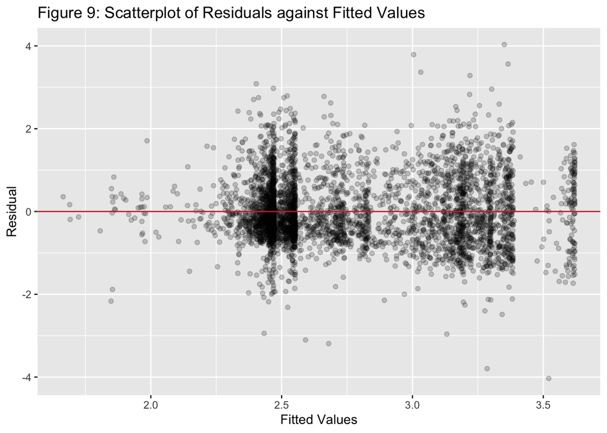

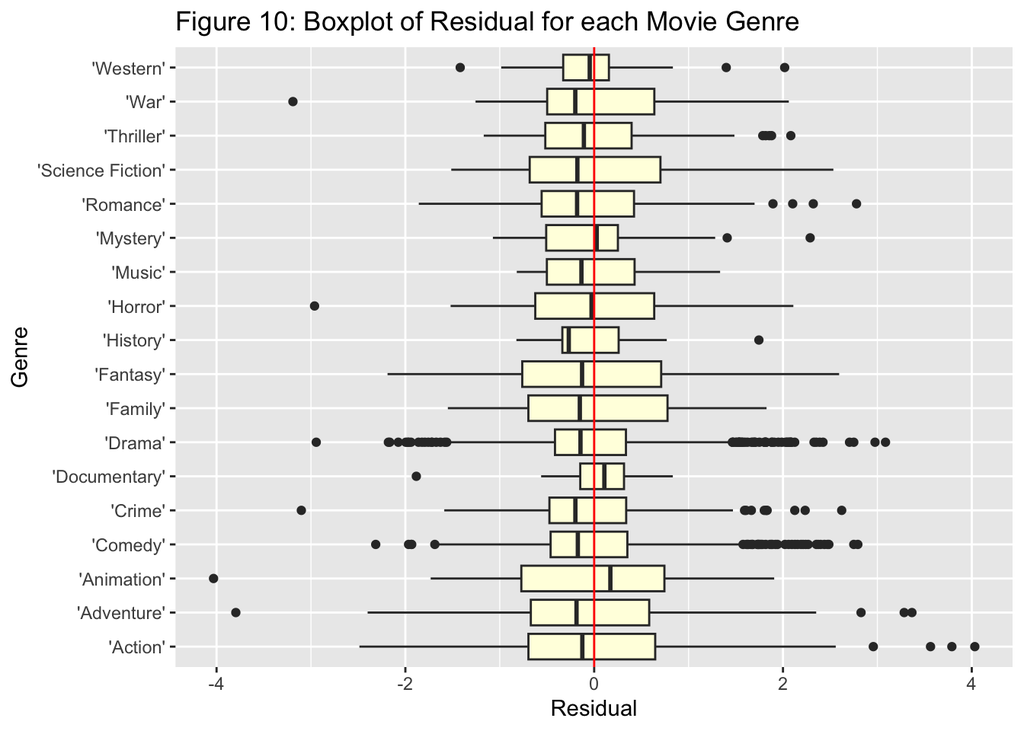

The residual models were normally distributed. The histogram (Figure 7) has a normal distribution, while the scatterplots (Figures 8 and 9) have an even number of point above and below the line (indicating that the overestimation and underestimation is occurring at the same rate). Additionally, the boxplots (Figure 10) have a relatively even spread above and below the residual line. The graph demonstrates outliers, however, they seem to be distributed evenly on both sides of the residual. Based on the residual analysis, the assumptions for inference in multiple linear regression are well met.

## 4. Discussion

### 4.1 Conclusions

Since each genre has a different trend, than it could be concluded that genre influences the relationship between percentage of female representation and popularity.

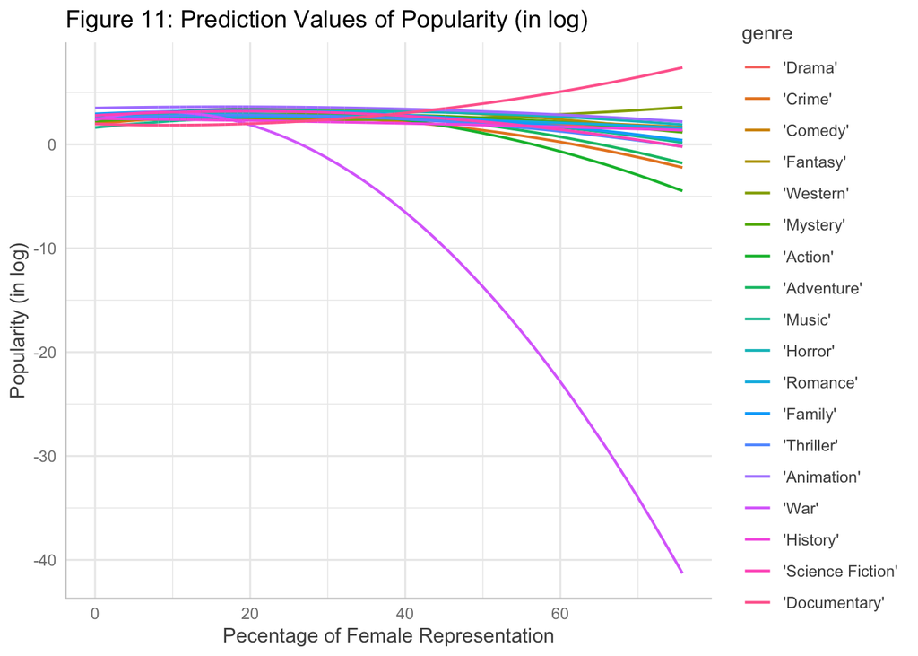

## 5. Citations

1. Lauzen, Martha M. *Streaming Women: Representation and Employment in Original U.S. Films Released by Streaming Services in 2022.* SDSU Center for the Study of Women in Television and Film, 2023. [https://womenintvfilm.sdsu.edu/research/#:~:text=In%202022%2C%20women%20comprised%2026,](https://womenintvfilm.sdsu.edu/research/#:~:text=In%202022%2C%20women%20comprised%2026,%2C%20and%2030%25%20of%20editors)

   %2C%20and%2030%25%20of%20editors.
2. Lauzen, Martha M. *It’s a Man’s (Celluloid) World: Portrayals of Female Characters in the Top Grossing U.S. Films of 2022.* SDSU Center for the Study of Women in Television and Film, 2023. [https://womenintvfilm.sdsu.edu/research/#:~:text=In%202022%2C%20women%20comprised%2026,](https://womenintvfilm.sdsu.edu/research/#:~:text=In%202022%2C%20women%20comprised%2026,%2C%20and%2030%25%20of%20editors)

   %2C%20and%2030%25%20of%20editors.
3. Rosa, Hellen, Porto, João V., and Murayama, Laura. *Female Representation in Cinema*. Kaggle, Jun. 2022. Web. Nov. 2023. https://www.kaggle.com/datasets/vinifm/female-representation-in-cinema.